# CÁLCULO DIFERENCIAL E INTEGRAL

# FUNCIONES Y SUS LÍMTIES

## CÓMPUTO DE LÍMITES

El cálculo preciso de límites requiere reglas precisas, que a continuación enunciamos e ilustramos:

- El límite de una suma es la suma de los límites
- El límite de una resta es la resta de los límites
- El límite de un constante por una función es la constante por el límite de la función
- El límite del producto es el producto de los límites
- El límite de un cociente es el cociente de los límite **siempre y cuando el límite del denominador sea diferente de cero**

Cómo se observa, calcular límites con operaciones básicas es sencillo, **excepto cuando tenemos divisiones entre cero**. Aquí tenemos que distinguir dos casos fundamentales:

### Singularidades removibles

En el primero, podemos remover la división entre cero con algún procedimiento álgebraico o geométrico. Consideremos un par de ejemplos.

#### Ejemplo

Sea $$f(x)=\dfrac{x^2-1}{x-1}$$. Cálcule el límite cuando $x\to 1$.

```python
#definimos f
f(x) = (x^2-1)/(x-1)
show(f)
```

$$\newcommand{\Bold}[1]{\mathbf{#1}}x \ {\mapsto}\ \frac{x^{2} - 1}{x - 1}$$

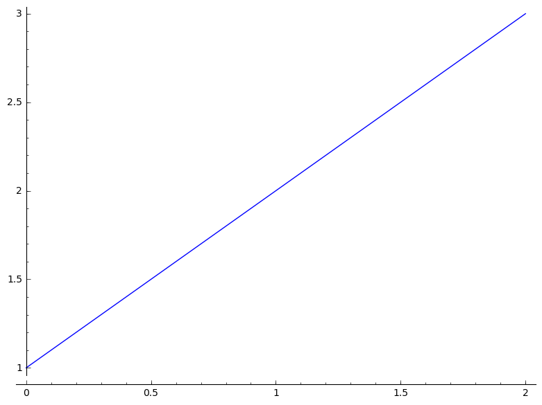

```python
#trazamos su gráfica
grafica = plot(f, (x,0,2))
show(grafica)
```

Al observar la gráfica, no observamos irregularidad alguna. De hecho, parecería que la función no es más que una línea recta y, en efecto, lo es...

```python
show(f.full_simplify())
```

$$\newcommand{\Bold}[1]{\mathbf{#1}}x + 1$$

... excepto en un punto:

```python
try:
    f(1)
    print("Cálculo exitoso")
except ValueError:
    print("Division entre cero")
```

```
Division entre cero
```

Aún así, es posible calcular el límite que esperaríamos de la simplificación, a saber

$$ \lim_{x\to 1} f(x) = \lim_{x\to 1} x+1 = 2$$

```python
L = limit(f(x), x=1)
print(L)
```

```
2
```

#### Ejercicio

Definamos la función

$$g(x) = \dfrac{\sin(x)}{x}$$

- Trace su gráfica alrededor de $x=0$
- Intente cálcular el valor en $x=0$
- Intente simplificar la expresión
- De la gráfica, intuya cual es su límite cuando $x \to 0$
- Cálcule dicho límite

### Singularidades irremovibles

Existen otro tipo de singularidades al intentar dividir entre cero, que no es posible evitar.

El ejemplo típico de esto sería $$ f(x) = \dfrac{1}{x} $$ cuando $x=0$.

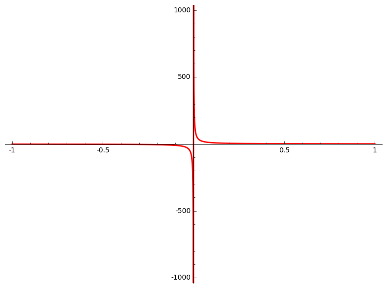

```python
### definimos f y graficamos
f(x) = 1/x
grafica = plot(f, (x,-1,1), thickness = 2, color = "red")
show(grafica, ymin=-1000, ymax=1000)
```

Incluso podemos tratar de calcular el límite, pero no obtendremos algún número real

```python
print(limit(f, x=0))
```

```
x |--> Infinity
```

**Observación**

En el ejemplo anterior, $f(x)\to \infty$ si $x\to 0$ por la derecha. ¿Cuál es el límite por la izquierda?

#### Ejercicio

Determine las sigularidade de $$ g(x)= \dfrac{x^{2} + x - 6}{x^{2} + 6 \, x + 9} $$ y su tipo.

*Sugerencia: Utilice el método `factor` para simplificar la expresión.*

### Límites de polinomios

De las reglas anteriores, es fácil cálcular el límite de cualquier combinación lineal de límites

$$ \lim_{x\to a} c_1 f(x) + c_2 g(x) = c_1 \lim_{x\to a} f(x) + c_2 \lim_{x\to a} g(x) $$

donde $c_1,c_2$ son constantes y el límite de potencias *naturales*

$$ \lim_{x\to a} \left(f(x)\right)^n = \left( \lim_{x\to a} f(x) \right)^n $$

donde $n=0,1,2,...$.

Otro par de reglas intuitivas que nos ayudarán a aterrizar nuestras ideas son las siguientes:

$$ \lim_{x \to a} c = c$$

$$ \lim_{x \to a} x = a$$

Con esto, podemos concluir que si $p(x)$ es un polinomio, entonces $$ \lim_{x \to a} p(x) = p(a)$$.

```python
### ejemplo
p(x) = 2*x^2-3*x+1
print(p(0))

L = limit(p, x=0)
print(L)
```

```
1
x |--> 1
```

Más aun, si $R(x)$ es una función racional de la forma $$ R(x) = \dfrac{p(x)}{q(x)} $$ con, $p,q$ polinomios, entonces: $$ \lim_{x \to a} R(x) = R(a)$$ **siempre y cuando $$q(a)\neq 0$$** (¿porqué?)

```python
### ejemplo
p(x) = x-2
q(x) = x-3

x0 = 1

print(q(x0))
print(p(x0))
```

```
-2
-1
```

```python
R(x) = p(x)/q(x)
print(R(x0))
```

```
1/2
```

```python
L = limit(R, x=x0)
print(L)
```

```
x |--> 1/2
```

¿Qué sucede cuando cambiamos $x_0=3$?

### Potencias reales

Finalmente, tenemos que considerar funciones de la forma $$ f(x) = x^{\alpha} $$ donde $\alpha$ es cualquier número real.

Como casos particulares tenemos

- $\alpha$ es una número racional $$x^{n/m} = \sqrt[m]{x^n}$$
- $\alpha$ es un número negativo $$x^{-n} = \dfrac{1}{x^n} $$

En cualquier caso, debemos tomar en cuenta sus dominio y que no es posible calcular límites en el interior de su complemento.

### Ejemplo

¿Es posible calcular $\lim_{x \to 0} (x-1)^{5/2}$?

[output not shown]

[figure not shown]

```python
f(x) = (x-1)^(5/2)
plot(f)
```

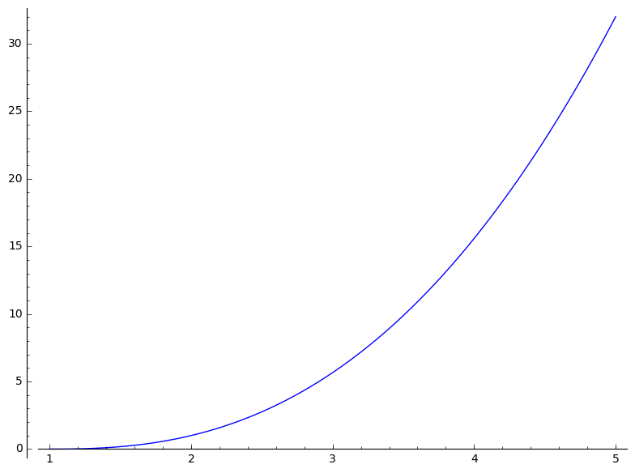

```python
plot(f, (x,1,5))
```

Para determinar su dominio, tendríamos que averiguar para que valores de $x$, la expresión $x-1$ es positiva:

```python
solve(x-1>0, x)
```

```
[[x > 1]]
```

#### Ejercicio

Para los siguientes límites:

- Trace la gráfica de la función correspondiente
- Determine si existe una singularidad y de que tipo
- Cálcule el límite
1. $$ \lim_{h \to 0} \dfrac{(3+h)^2-9}{h}$$
2. $$ \lim_{t \to 0} \dfrac{\sqrt{t^2+9}-3}{t^2} $$
3. $$ \lim_{x \to 0} |x| $$
4. $$ \lim_{x \to 0} \dfrac{|x|}{x} $$

#### Ejercicio

- Investigue las [funciones de parte entera](https://es.wikipedia.org/wiki/Funciones_de_parte_entera) y sus implementaciones respectivas en `Sagemath` o `Python`.
- Trace sus gráficas correspondientes y discuta los límites laterales para cada número entero.

### Teorema del sandwich

Tratemos de averiguar gráficamente el valor de

$$ \lim_{x\to 0} x^2\sin\dfrac{1}{x} $$

el cual es claro no podemos obtener sólo por sustitución.

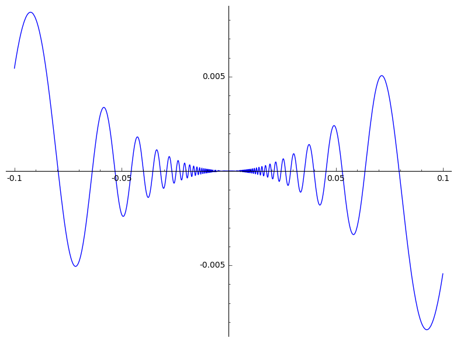

```python
f(x) = x^2*sin(1/x)
intervalo = (x,-0.1,0.1)
grafica = plot(f, intervalo)
show(grafica)
```

Podríamos adivinar que se acerca a cero. Pero podemos hacer esto más claro, comparando la gráfica de $f(x)$ con la de las funciones $x\mapsto \pm x^2$

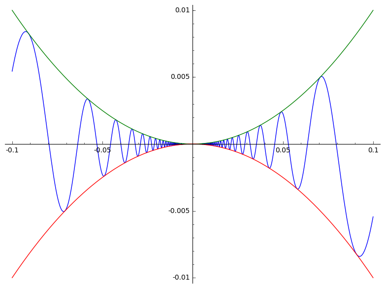

```python
grafica += plot(x^2, intervalo, color="green")
grafica += plot(-x^2, intervalo, color="red")
show(grafica)
```

De hecho, se puede demostrar formalmente que $$ -x^2 \leq x^2\sin(1/x) \leq x^2 $$ para todo $$x\neq 0$$ y como $$ \lim_{x\to 0}-x^2 = \lim_{x\to 0}x^2 = 0 $$ entonces deducimos que $$ \lim_{x\to 0} x^2\sin\dfrac{1}{x} = 0 $$

Este resultado se conoce como **teorema del sandwich** que se enuncia de la siguiente manera

#### Teorema

Si $$m(x) \leq f(x) \leq M(x)$$ cuando $x \neq c$ pero es cercano a $c$ y $$ \lim_{x\to c} m(x) = \lim_{x\to c} M(x) = L$$ entonces $$ \lim_{x\to c} f(x) = L $$

#### Ejercicio

1. Trace la gráfica de $m(x)=\cos(t)$ cuando $t\approx 0$
2. Trace la gráfica de $M(x)=1$ cuando $t\approx 0$
3. Trace la gráfica de $f(x)=\dfrac{\sin(t)}{t}$ cuando $t\approx 0$
4. Valore el límite de $f(x)$ cuando $t\to 0$ utilizando el teorema del sandwich.

#### Ejercicio

Evalue

1. $$ \lim_{t \to 0}\dfrac{\sin(7t)}{4t} $$
2. $$ \lim_{t \to 0}\dfrac{\cos(t)-1}{t} $$